# Nback Notebook

TODO: deal with first trial for oneback and first two trials for twoback -current solution is to eliminate trials that are accurate with a RT of 0.

# NBACK PRE DATA ANALYSIS

N=56 (Control+Experimental) There is a 3rd undefined group for those that have completed this task, but have dropped out for one reason or another.

## Data Prep

Getting the Data ready for analysis Defaults: R uses dummy coding as it’s default. In this sample, the control group and the 1-Back will be the dummy variables in the analysis. So all Estimates are relative to these dummy variables

### Load Requisite R Packages

note: some of these may not actually be used.

```r
library(ggplot2)
library(lme4)
library(languageR)
library(lmerTest)
library(influence.ME)
library(dplyr) # magic
library(scales) #for making percents on the y-axis of graphs
```

### Read in the dataset (in current directory)

```r
Nback_data = read.table("Nback_R_format.csv", header = TRUE, sep = ",")
```

### Omit missing data (e.g. from practice trials)

```r
Nback_data[Nback_data==""] <- NA
#my current solution to deal with the first trials of one-back and twoback
Nback_data$RT[Nback_data$RT==0 & Nback_data$ACC==1] <- NA
Nback_data = na.omit(Nback_data)
head(Nback_data, n = 20)
```

|  | subject | group | session | stimtype | ACC | RT |
| --- | --- | --- | --- | --- | --- | --- |
| 15 | 5 | Experimental | 1 | singleBl | 1 | 686 |
| 16 | 5 | Experimental | 1 | singleBl | 1 | 731 |
| 17 | 5 | Experimental | 1 | singleBl | 1 | 439 |
| 18 | 5 | Experimental | 1 | singleBl | 1 | 836 |
| 19 | 5 | Experimental | 1 | singleBl | 1 | 769 |
| 20 | 5 | Experimental | 1 | singleBl | 1 | 717 |
| 21 | 5 | Experimental | 1 | singleBl | 1 | 666 |
| 22 | 5 | Experimental | 1 | singleBl | 1 | 823 |
| 23 | 5 | Experimental | 1 | singleBl | 1 | 610 |
| 24 | 5 | Experimental | 1 | singleBl | 1 | 415 |

[output cut: 10 more lines]

### Omit the Undefined group from the data and specify group as a factor

```r
Nback_data <- subset(Nback_data,group=="Control" | group=="Experimental")
Nback_data$group <- factor(Nback_data$group)
summary(Nback_data)
```

```
    subject               group          session        stimtype          ACC
 Min.   :  5.0   Control     :10747   Min.   :1.0           :    0   Min.   :0.0000
 1st Qu.: 45.0   Experimental:10000   1st Qu.:1.0   singleBl:10649   1st Qu.:1.0000
 Median : 98.0                        Median :1.0   twoBlock:10098   Median :1.0000
 Mean   :103.3                        Mean   :1.5                    Mean   :0.9088
 3rd Qu.:164.0                        3rd Qu.:2.0                    3rd Qu.:1.0000
 Max.   :209.0                        Max.   :2.0                    Max.   :1.0000
       RT
 Min.   :   0.0
 1st Qu.: 650.0
 Median : 838.0
 Mean   : 888.7
 3rd Qu.:1103.0
 Max.   :1999.0
```

```r
contrasts(Nback_data$group)
```

```
             Experimental
Control                 0
Experimental            1
```

### Omit the Undefined stimtype and specify stimtype as a factor

```r
Nback_data <- subset(Nback_data,stimtype=="singleBl" | stimtype=="twoBlock")
Nback_data$stimtype <- factor(Nback_data$stimtype)
summary(Nback_data)
```

```
    subject               group          session        stimtype          ACC
 Min.   :  5.0   Control     :10747   Min.   :1.0   singleBl:10649   Min.   :0.0000
 1st Qu.: 45.0   Experimental:10000   1st Qu.:1.0   twoBlock:10098   1st Qu.:1.0000
 Median : 98.0                        Median :1.0                    Median :1.0000
 Mean   :103.3                        Mean   :1.5                    Mean   :0.9088
 3rd Qu.:164.0                        3rd Qu.:2.0                    3rd Qu.:1.0000
 Max.   :209.0                        Max.   :2.0                    Max.   :1.0000
       RT
 Min.   :   0.0
 1st Qu.: 650.0
 Median : 838.0
 Mean   : 888.7
 3rd Qu.:1103.0
 Max.   :1999.0
```

```r
contrasts(Nback_data$stimtype)
```

```
         twoBlock
singleBl        0
twoBlock        1
```

### Isolate the session to the first session

```r
#Isolate Pre data
Nback_data_pre <- subset(Nback_data, session==1)
#Specify Pre session as a factor.
Nback_data_pre$session <- factor(Nback_data_pre$session)
summary(Nback_data_pre)
```

```
    subject               group      session       stimtype         ACC
 Min.   :  5.0   Control     :5373   1:10374   singleBl:5325   Min.   :0.0000
 1st Qu.: 45.0   Experimental:5001             twoBlock:5049   1st Qu.:1.0000
 Median : 98.0                                                 Median :1.0000
 Mean   :103.3                                                 Mean   :0.8958
 3rd Qu.:165.5                                                 3rd Qu.:1.0000
 Max.   :209.0                                                 Max.   :1.0000
       RT
 Min.   :   0.0
 1st Qu.: 684.2
 Median : 876.5
 Mean   : 919.7
 3rd Qu.:1149.8
 Max.   :1999.0
```

### specify subject as a factor

```r
Nback_data_pre$subject <- as.factor(Nback_data_pre$subject)
summary(Nback_data_pre)
```

```
    subject              group      session       stimtype         ACC
 159    : 188   Control     :5373   1:10374   singleBl:5325   Min.   :0.0000
 182    : 188   Experimental:5001             twoBlock:5049   1st Qu.:1.0000
 74     : 187                                                 Median :1.0000
 140    : 187                                                 Mean   :0.8958
 8      : 186                                                 3rd Qu.:1.0000
 24     : 186                                                 Max.   :1.0000
 (Other):9252
       RT
 Min.   :   0.0
 1st Qu.: 684.2
 Median : 876.5
 Mean   : 919.7
 3rd Qu.:1149.8
 Max.   :1999.0
```

## NBack Accuracy Analysis

### Print out binary accuracy data for each subject for each group

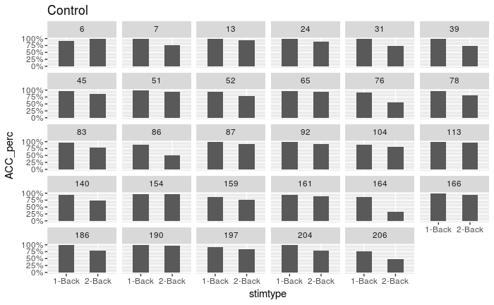

```r
#Control Group Data
Nback_data_pre_control <- subset(Nback_data_pre, group=="Control")
#change binary data to a percent
Nback_data_pre_control_percent <- ddply(Nback_data_pre_control, .(stimtype, subject), summarize, ACC_perc = mean(ACC))
#Experimental Group Data
Nback_data_pre_experimental <- subset(Nback_data_pre, group=="Experimental")
#change binary data to a percent
Nback_data_pre_experimental_percent <- ddply(Nback_data_pre_experimental, .(stimtype, subject), summarize, ACC_perc = mean(ACC))
ggplot(data = Nback_data_pre_control_percent, aes( x = stimtype, y = ACC_perc)) + geom_bar(stat = "identity", width = 0.5) + facet_wrap(~subject) + scale_y_continuous(labels=percent) + scale_x_discrete(labels=c("1-Back","2-Back")) + ggtitle("Control")
```

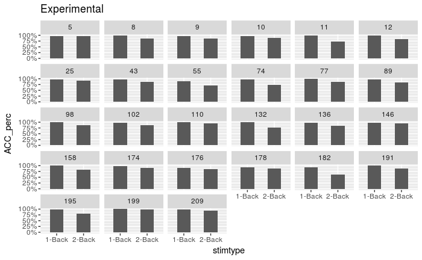

```r
ggplot(data = Nback_data_pre_experimental_percent, aes( x = stimtype, y = ACC_perc)) + geom_bar(stat = "identity", width = 0.5) + facet_wrap(~subject) + scale_y_continuous(labels=percent) +  scale_x_discrete(labels=c("1-Back","2-Back")) + ggtitle("Experimental")
```

### Model Accuracy (Logit)

Testing for main effects of and interactions between group (Exp and Con) and stimtype (1-Back and 2-Back) using random intercepts for subjects to account for variability between subjects. Since the response variable (ACC) contains 1’s and 0’s, I’m using a Logistic model for the data.

[output not shown]

```
Generalized linear mixed model fit by maximum likelihood (Laplace Approximation) ['glmerMod']
 Family: binomial  ( logit )
Formula: ACC ~ group * stimtype + (1 | subject)
   Data: Nback_data_pre

     AIC      BIC   logLik deviance df.resid
  3498.4   3534.3  -1744.2   3488.4     9760

Scaled residuals:
     Min       1Q   Median       3Q      Max
-11.9260   0.1235   0.1739   0.2455   0.6584

Random effects:
 Groups  Name        Variance Std.Dev.
 subject (Intercept) 0.4385   0.6622
Number of obs: 9765, groups:  subject, 56

Fixed effects:
                                   Estimate Std. Error z value Pr(>|z|)
(Intercept)                         3.96466    0.18210  21.772   <2e-16 ***
groupExperimental                   0.08814    0.26323   0.335    0.738
stimtypetwoBlock                   -1.45920    0.14781  -9.872   <2e-16 ***
groupExperimental:stimtypetwoBlock  0.12508    0.21968   0.569    0.569
---
Signif. codes:  0 ‘***’ 0.001 ‘**’ 0.01 ‘*’ 0.05 ‘.’ 0.1 ‘ ’ 1

Correlation of Fixed Effects:
            (Intr) grpExp stmtyB
grpExprmntl -0.682
stmtyptwBlc -0.615  0.423
grpExprmn:B  0.412 -0.625 -0.672
```

**Conclusion**: 2-Back is significantly less accurate than 1-Back (as expected), but no group effect or groupxstimtype interaction (as expected)

## NBack Reaction Time Analysis

### Format RT data

(subset for RTs when they are accurate, greater than 200ms, and less than 2000 ms) See how many observations are lost when we subset the data

```r
#all observations
print("All Data")
```

```
[1] "All Data"
```

```r
All_data <- length(Nback_data_pre$RT)
summary(Nback_data_pre)
```

```
    subject              group      session       stimtype         ACC               RT
 159    : 188   Control     :5373   1:10374   singleBl:5325   Min.   :0.0000   Min.   :   0.0
 182    : 188   Experimental:5001             twoBlock:5049   1st Qu.:1.0000   1st Qu.: 684.2
 74     : 187                                                 Median :1.0000   Median : 876.5
 140    : 187                                                 Mean   :0.8958   Mean   : 919.7
 8      : 186                                                 3rd Qu.:1.0000   3rd Qu.:1149.8
 24     : 186                                                 Max.   :1.0000   Max.   :1999.0
 (Other):9252
```

```r
#remove innacurate responses
print("Removed innacurate trials (from all data dataframe)")
```

```
[1] "Removed innacurate trials (from all data dataframe)"
```

```r
Nback_data_pre_RT <- subset(Nback_data_pre, ACC==1)
ACC_filt_data <- length(Nback_data_pre_RT$RT)
summary(Nback_data_pre_RT)
```

```
    subject              group      session      stimtype         ACC          RT
 199    : 183   Control     :4725   1:9293   singleBl:5117   Min.   :1   Min.   :  23.0
 190    : 182   Experimental:4568            twoBlock:4176   1st Qu.:1   1st Qu.: 717.0
 113    : 181                                                Median :1   Median : 892.0
 13     : 180                                                Mean   :1   Mean   : 967.7
 51     : 180                                                3rd Qu.:1   3rd Qu.:1154.0
 154    : 180                                                Max.   :1   Max.   :1999.0
 (Other):8207
```

```r
#remove short and long RTs
print("Removed slow and fast RTs")
```

```
[1] "Removed slow and fast RTs"
```

```r
Nback_data_pre_RT <- subset(Nback_data_pre_RT, RT>200 & RT<2000)
filt_data <- length(Nback_data_pre_RT$RT)
summary(Nback_data_pre_RT)
```

```
    subject              group      session      stimtype         ACC          RT
 199    : 183   Control     :4719   1:9286   singleBl:5115   Min.   :1   Min.   : 237.0
 113    : 181   Experimental:4567            twoBlock:4171   1st Qu.:1   1st Qu.: 718.0
 190    : 181                                                Median :1   Median : 893.0
 13     : 180                                                Mean   :1   Mean   : 968.4
 51     : 180                                                3rd Qu.:1   3rd Qu.:1154.8
 154    : 180                                                Max.   :1   Max.   :1999.0
 (Other):8201
```

```r
print("Percent Data Removed (from RT filtering)")
```

```
[1] "Percent Data Removed (from RT filtering)"
```

```r
perc_data_rm <- (1 - (filt_data/ACC_filt_data))*100
perc_data_rm
```

```
[1] 0.07532551
```

**Conclusion**: barely any RTs are removed, I’m not worried about this

### graph RT data

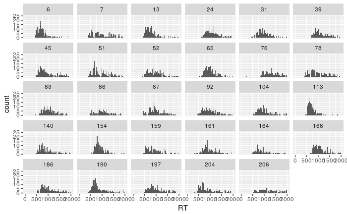

```r
#hist(subset(Nback_data_pre_RT, group=="Control")$RT,ylim=c(0,800))
#hist(subset(Nback_data_pre_RT, group=="Experimental")$RT,ylim=c(0,800))
Nback_data_pre_RT_control <- subset(Nback_data_pre_RT, group=="Control")
Nback_data_pre_RT_experimental <- subset(Nback_data_pre_RT, group=="Experimental")
#collapsing across stimtype (1-back and 2-back), not enough data to make a good histogram, and the graphs become too crowded if I include stimtype as a facet
RT_hist_control <- ggplot(data = Nback_data_pre_RT_control, aes(RT)) + geom_histogram(binwidth = 30) + facet_wrap(~subject) + scale_y_continuous(limits = c(0,25)) + scale_x_continuous(limits = c(0,2000))
print(RT_hist_control)
```

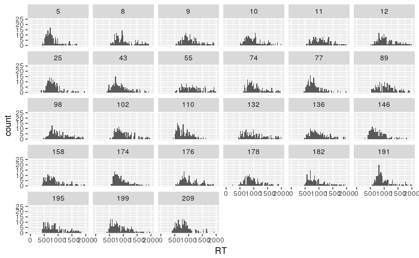

```r
RT_hist_experimental <- ggplot(data = Nback_data_pre_RT_experimental, aes(RT)) + geom_histogram(binwidth = 30) + facet_wrap(~subject) + scale_y_continuous(limits = c(0,25)) + scale_x_continuous(limits = c(0,2000))
print(RT_hist_experimental)
```

**Conclusion**: RT data shows classic right skew for almost all the participants, going to transform the RT data to make them normally distributed

### Log Transform RT data to make them normally distributed

```r
Nback_data_pre_RT$log_RT <- log(1/Nback_data_pre_RT$RT)
```

### Graph log_RT data

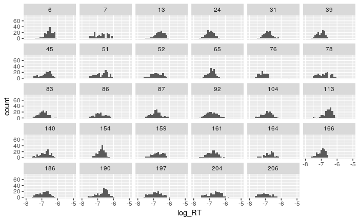

```r
Nback_data_pre_RT_control <- subset(Nback_data_pre_RT, group=="Control")
Nback_data_pre_RT_experimental <- subset(Nback_data_pre_RT, group=="Experimental")
#collapsing across stimtype (1-back and 2-back), not enough data to make a good histogram, and the graphs become too crowded if I include stimtype as a facet
RT_hist_control <- ggplot(data = Nback_data_pre_RT_control, aes(log_RT)) + geom_histogram(binwidth = .1) + facet_wrap(~subject) + scale_y_continuous(limits = c(0,75)) + scale_x_continuous(limits = c(-8,-5))
print(RT_hist_control)
```

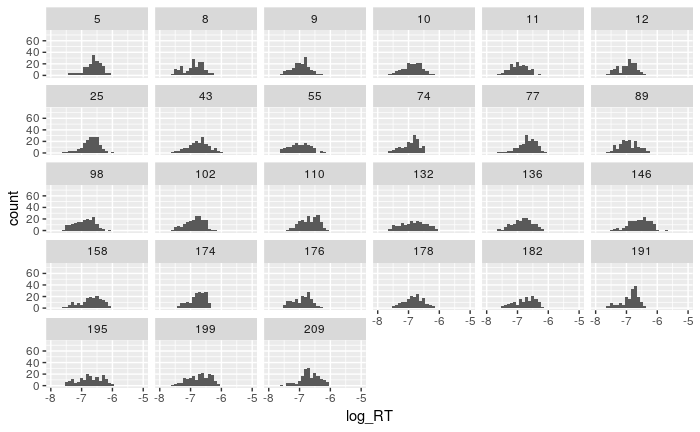

```r
RT_hist_experimental <- ggplot(data = Nback_data_pre_RT_experimental, aes(log_RT)) + geom_histogram(binwidth = .1) + facet_wrap(~subject) + scale_y_continuous(limits = c(0,75)) + scale_x_continuous(limits = c(-8,-5))
print(RT_hist_experimental)
```

**Conclusion**: The log transformed RT data looks more normally distributed. Going to use the log transformed RTs in the linear model

### Model log_RT (lmer)

Testing for main effects of and interactions between group (Exp and Con) and stimtype (1-Back and 2-Back) using random intercepts for subjects to account for variability between subjects. The response variable is a continuous, normally distributed variable (Reaction Time), so I am using a regular linear model with random subject intercepts (account for mean differences)

```r
Nback_RT_model <- lmer(log_RT ~ group*stimtype + (1|subject), data = Nback_data_pre_RT)
summary(Nback_RT_model)
```

```
Linear mixed model fit by REML
t-tests use  Satterthwaite approximations to degrees of freedom ['lmerMod']
Formula: log_RT ~ group * stimtype + (1 | subject)
   Data: Nback_data_pre_RT

REML criterion at convergence: 2571.6

Scaled residuals:
    Min      1Q  Median      3Q     Max
-3.7900 -0.6449  0.0531  0.6503  6.5123

Random effects:
 Groups   Name        Variance Std.Dev.
 subject  (Intercept) 0.01631  0.1277
 Residual             0.07539  0.2746
Number of obs: 9286, groups:  subject, 56

Fixed effects:
                                     Estimate Std. Error         df  t value Pr(>|t|)
(Intercept)                        -6.694e+00  2.432e-02  5.600e+01 -275.258   <2e-16 ***
groupExperimental                   1.884e-02  3.501e-02  5.600e+01    0.538    0.593
stimtypetwoBlock                   -3.069e-01  8.076e-03  9.233e+03  -37.999   <2e-16 ***
groupExperimental:stimtypetwoBlock -5.510e-03  1.149e-02  9.231e+03   -0.480    0.632
---
Signif. codes:  0 ‘***’ 0.001 ‘**’ 0.01 ‘*’ 0.05 ‘.’ 0.1 ‘ ’ 1

Correlation of Fixed Effects:
            (Intr) grpExp stmtyB
grpExprmntl -0.695
stmtyptwBlc -0.146  0.102
grpExprmn:B  0.103 -0.146 -0.703
```

**Conclusion**: No group differences (as expected) and the 2-Back is slower (I think) than the 1-Back (as expected)